# Homework 3 - functions and dplyr

Tim Dennis & Reid Otsuji

1/22/2018

## Due 1/31 - By Midnight

### How to submit your homework:

1. Download the `r-homework3-funct-dplyr.Rmd` Rmarkdown file and open in Rstudio
2. Rename `r-homework3-funct-dplyr.Rmd` to `yourlastname_sudentID_r-homework3.R`
3. Type the answers in the code chunks.
4. Save the Rmarkdown file.
5. Upload the file to TritonEd for Assignment 3.

## load packages and assign gapminder data before you start the assignment:

```r
# load packages dplry, tidyr, ggplot2
library(dplyr)
library(tidyr)
library(ggplot2)
```

```r
# assign gapminder data
gapminder <- read.csv('gapminder-FiveYearData.csv') #use your file path
```

## Questions:

##### 1. Write a function called `weighted_mean` that takes a `gapminder` data.frame as an argument and calculates a trimmed or weighted mean of life expectancy by weighing by population. To do this you will assign the output of a function that calculates the the sum of `lifeExp` times `pop` divided by the `sum of pop` to a `weighted_mean` object. Hint: Look up the `?sum` function.

```r
weighted_mean <- function(gapminder) {
  # 1. complete your weighted mean formula here:
  weighted_mean = sum(  )
  # 2. complete return
  return()
}
```

##### 2. Use dplyr to filter only rows with the continent of Africa.

```r
# 1. compelte your code here:
gapminder %>%
  filter( ) %>%

# 2. verify filter using the head()
```

##### 3. Using the filtered `gapminder` data from the last question (only ‘Africa’ rows), with your `weighted_mean` function in question 1, what is the weighted mean of life expectancy of Africa?

```r
# 1. complete the code here (don't forget %>% )
gapminder_ afr <-
  filter()
  weighted_mean()
```

##### 4. Create a `dplyr` piped sequence that:

[output not shown]

Note: You’ll need to use the `summarize` function that `dplyr` gives you.

```r
# 1. write your code here:
weighted_mean_dp <- gapminder %>%
  summarize(

  )

# 2. display output
```

##### 5. Using the built in `iris` dataset, `dplyr`, `tidyr`, and `ggplot2`, write a script that creates a plot comparing the petal and sepal widths and lengths values for each species of flower.

Hint: Start by using tidyr `gather()` function to create a `flowers_df` data frame gathering `Sepal.Length`, `Sepal.Width`, `Petal.Length`, and `Petal.Width` into the key values with `variable` being the ID variable and `value` being the measures. Hint: To express variables you want to `gather` you can use a function like `startsWith()` or use the exclusion operator `-` to tell gather that you want to include everthing but the excluded (e.g `-Species`).

Next use `dplyr` and `ggplot` to create a bar plot comparing the species and values with the geom properties `stat = "identity"` and `position = "dodge"`.

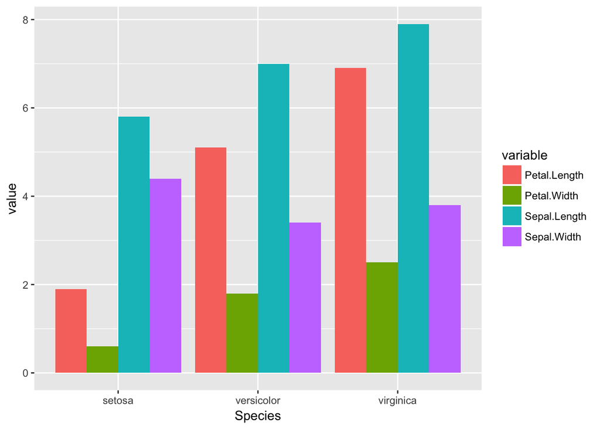

Plot Sample

```r
# complete code here:
flowers_df <- gather()
flowers_df %>%
  ggplot()
```